# DSA2101 Midterms

Michelle Yong Pei Feng A0221827H

10/11/2021

```r
#Question 2.1
resale1 <- read.csv("../data/resale1.csv") %>% as_tibble()
resale2 <- read.csv("../data/resale2.csv") %>% as_tibble()

resale2 <- resale2 %>%
  mutate(remaining_lease = as.integer(str_extract(remaining_lease,"^.{2}"))) %>%
  mutate(month = ifelse(month == "2020-Aug", "2020-08", month))

resale_prices <- full_join(resale1, resale2) %>%
  mutate(town = toupper(town))
#Question 2.2
resale_prices <- resale_prices %>%
  mutate(price_psm = resale_price/floor_area_sqm,
         lstorey = as.integer(str_extract(storey_range,"^.{2}")),
         ustorey = as.integer(str_extract(storey_range, ".{2}$"))) %>%
  separate(month, c("year", "month"), sep="-") %>%
  mutate(month = as.numeric(month),
         year = as.numeric(year),
         town = ifelse(town=="KALLANG/WHAMPOA", "CENTRAL AREA", town))

#Question 2.3
CPI_csv <- read.csv("../data/CPI_data.csv", skip=10, head=TRUE) %>%
  as_tibble()

CPI_data <- slice_head(CPI_csv, n=1) %>%
  rownames_to_column() %>%
  select(-Data.Series) %>%
  mutate(rowname = "CPI") %>%
  gather("month", "CPI", -rowname) %>%
  spread(rowname, "CPI") %>%
  mutate(year = as.integer(str_extract(month,"[[:digit:]]{4}"))) %>%
  mutate(month = match(str_sub(month,-3,-1), month.abb),
         CPI = as.numeric(CPI)) %>%
  filter(year>2014) %>%
  arrange(year, month)

resale_prices <- left_join(resale_prices, CPI_data, by = c("year", "month")) %>%
  mutate(price_psm_adj = CPI/100*price_psm)

median_prices <- resale_prices %>%
  filter(!is.na(price_psm_adj), flat_type == "4 ROOM") %>%
  group_by(year, month) %>%
  summarize(median_adj = median(price_psm_adj),
            median_unadj = median(price_psm)) %>%
  mutate(date = make_date(year,month))
```

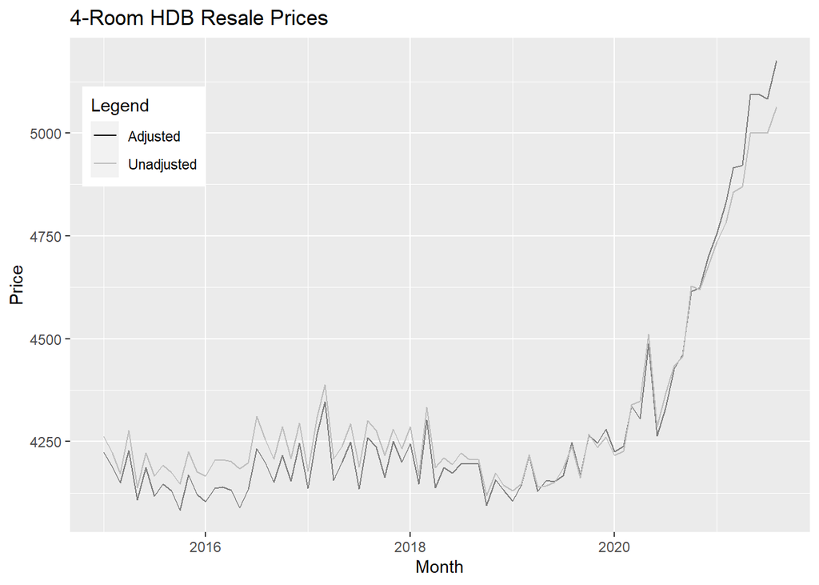

```r
ggplot(median_prices, aes(x=date)) +
  geom_line(aes(y=median_adj, color="black")) +
  geom_line(aes(y=median_unadj, color="grey"), color="grey") +
  scale_color_manual(name="Legend", values = c("Adjusted"="black",
                                               "Unadjusted"="grey")) +
  theme(legend.position = c(0.1,0.80)) +
  labs(title="4-Room HDB Resale Prices") +
  xlab("Month") +
  ylab("Price")
```

```r
#Question 2.4
med_price_town_tbl <- resale_prices %>%
  filter(year==2020 | (year==2021 & month<9), flat_type == "4 ROOM") %>%
  group_by(town) %>%
  summarize(median_adj = median(price_psm_adj))

#Question 2.5
plm <- function(x,y){
  combn_x <- combn(x,2)
  combn_y <- combn(y,2)
  diff_x <- apply(combn_x,2,function(x){x[2]-x[1]})
  diff_y <- apply(combn_y,2,function(x){x[2]-x[1]})
  gradient <- diff_y/diff_x
  gradient[!is.finite(gradient)] <- NA
  b_hat <- median(gradient, na.rm = TRUE)
  a_hat <- median(combn_y-b_hat*combn_x, na.rm = TRUE)
  return(c(b_hat, a_hat))
}

#Question 2.6
area_prices <- resale_prices %>%
  filter(year==2020 | (year==2021 & month<9)) %>%
  mutate(date = make_date(year,month)) %>%
  group_by(town, date) %>%
  mutate(med_price_psm_adj = median(price_psm_adj)) %>%
  select(town, med_price_psm_adj, date) %>%
  distinct()

plm_tbl <- area_prices %>%
  group_by(town) %>%
  summarize(plm_b = plm(date, med_price_psm_adj)[1],
            plm_a = plm(date, med_price_psm_adj)[2])

greatest_rate <- slice_max(plm_tbl, plm_b, n=3)
lowest_rate <- slice_min(plm_tbl, plm_b, n=3)
```

Queenstown, Choa Chu Kang and Central area had the greatest rate of increase in monthly median adjusted price, while Bukit Timah, Bukit Merah, and SengKang had the lowest rates.

```r
#Question 2.7
model_prices <- resale_prices %>%
  filter(year>2020) %>%
  group_by(flat_model, town) %>%
  count() %>%
  pivot_wider(id_cols=town, names_from=flat_model, values_from=n) %>%
  ungroup()
```

Examples of exclusive flat models include the Improved-Maisonette exclusive to Hougang, Type S1 and S2 flats exclusive to central areas. There are other models such as the Premium Apartment Loft, Premium Maisonette and Multi Generation flats limited to 2 or lesser towns.

```r
#Question 2.8
pln_areas <- readRDS("../data/sg_planning_areas.rds")
central <- c("KALLANG", "NOVENA", "TANGLIN", "DOWNTOWN CORE", "MUSEUM",
             "NEWTON", "ORCHARD", "OUTRAM", "RIVER VALLEY", "ROCHOR",
             "SINGAPORE RIVER")
pln_areas <- filter(pln_areas, pln_areas$PLN_AREA_N %in% central) %>%
  st_union() %>%
  st_union(pln_areas,.)
```

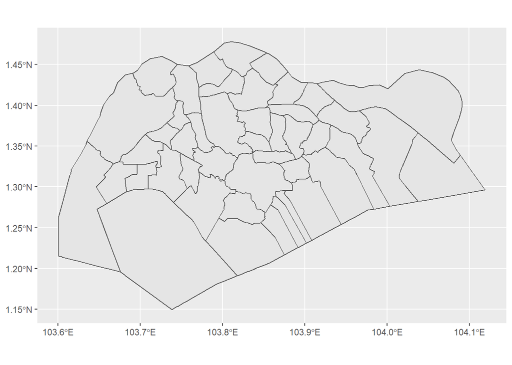

```r
ggplot(pln_areas) +
  geom_sf()
```

```r
#Question 2.9
# town_prices <- resale_prices %>%
#   filter(year==2015, flat_type=="4 ROOM") %>%
#   group_by(town) %>%
#   summarize(med_price_psm_adj=median(price_psm_adj)) %>%
#   left_join(pln_areas, by=c("town"="PLN_AREA_N"))
#
# st_touches(town_prices$geometry, st_geometry(a))
```

Question 2.10  
We may associate the growing demand for certain housing with the percentage increase in resale prices after every year. By analyzing the percentage change in prices for all areas in a year, we can plot a graph of percentage increase against floor area to linearize the relationship. If the plot shows a upward trend, we may conclude that there is greater demand for bigger houses. Similarly, plotting the graphs of percentage changes in price for central vs non-central areas in a given year can show which housing locations are more popular.